# It is Better to be Yourself: A Network Analysis on Mutual Fund Distinctiveness and Performance

Working Paper

Matthew Son  
09-21-2022

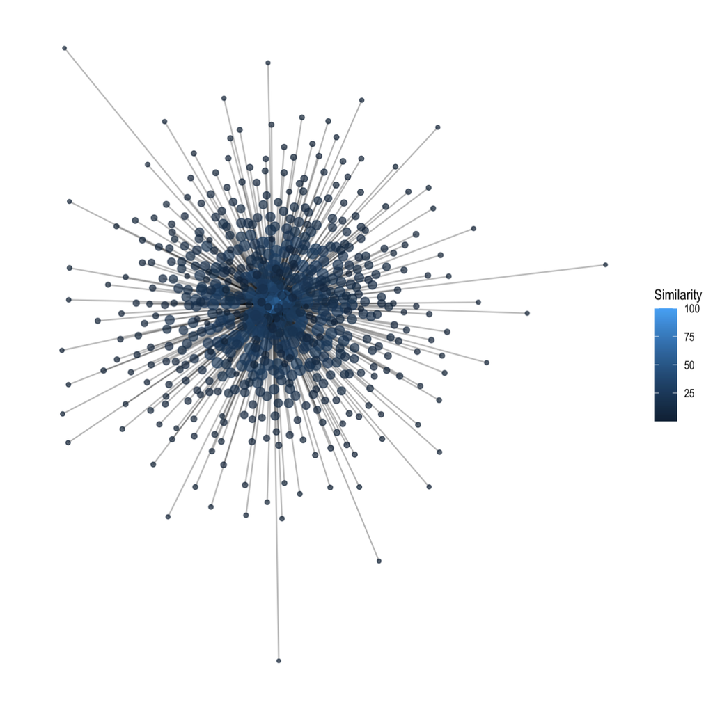

### Abstract

Do funds with distinctive holding perform better? This paper proposes a new, effective method to measure mutual funds’ portfolio distinctiveness with a network model and examines their performance. By analyzing 48 million fund network connections, we document two main findings: First, we find a strong association between portfolio distinctiveness and its long-term risk-adjusted return. We measure funds’ distinctiveness in two dimensions: centrality and clusteredness. The centrality measures the overall commonness of a fund’s portfolio, while clusteredness measures how strongly a fund is forming a clique (localized strategy). We find funds that hold assets commonly held by others (high centrality) under- perform by 60bps, while funds with localized and distinctive portfolios (high clusteredness) outperform 140 bps per year. Second, we find the effect of peer competition that monotonically harms the fund’s performance. Funds in the lowest quintile of competition outperform 240bps per year compared to top quintile funds. All results hold significance for more than 24 months. Our network-based approach overcomes potential confounding effects from style misclassifications and mixed-style funds.

### Download PDF

1. **Download PDF**
2. SSRN Link : Submitted